# Introduction to Cache

Eliot J. B. McIntire

January 07 2026

# 1 Reproducible workflow

As part of a reproducible workflow, caching of function calls, code chunks, and other elements of a project is a critical component. The objective of a reproducible workflow is is likely that an entire work flow from raw data to publication, decision support, report writing, presentation building etc., could be built and be reproducible anywhere, on any computer, operating system, with any starting conditions, on demand. The `reproducible::Cache` function is built to work with any R function.

## 1.1 Differences with other approaches

`Cache` users `DBI` as a backend, with key functions, `dbReadTable`, `dbRemoveTable`, `dbSendQuery`, `dbSendStatement`, `dbCreateTable` and `dbAppendTable`. These can all be accessed via `Cache`, `showCache`, `clearCache`, and `keepCache`. It is optimized for speed of transactions, using `digest::digest` on objects and files. The main function is superficially similar to `archivist::cache`, which uses `digest::digest` in all cases to determine whether the arguments are identical in subsequent iterations. It also but does *many* things that make standard caching with `digest::digest` don’t work reliably between systems. For these, the function `.robustDigest` is introduced to make caching transferable between systems. This is relevant for file paths, environments, parallel clusters, functions (which are contained within an environment), and many others (e.g., see `?.robustDigest` for methods). `Cache` also adds important elements like automated tagging and the option to retrieve disk-cached values via stashed objects in memory using `memoise::memoise`. This means that running `Cache` 1, 2, and 3 times on the same function will get progressively faster. This can be extremely useful for web apps built with, say `shiny`.

## 1.2 Function-level caching

Any function can be cached by wrapping `Cache` around the function call, or by using base pipe `|>`:

This will be a slight change to a function call, such as: `terra::project(raster, crs = terra::crs(newRaster))` to `Cache(terra::project(raster, crs = terra::crs(newRaster)))` or with the pipe, which may be more convenient as it is easy to add and remove caching in the code base: `terra::project(raster, crs = terra::crs(newRaster)) |> Cache()`

This is particularly useful for expensive operations.

```r
library(reproducible)
library(data.table)
```

```r
tmpDir <- file.path(tempfile(), "reproducible_examples", "Cache")
dir.create(tmpDir, recursive = TRUE)

# Source raster with a complete LCC definition
ras <- terra::rast(terra::ext(0, 300, 0, 300), vals = 1:9e4, res = 1)
terra::crs(ras) <- "+proj=lcc +lat_1=60 +lat_2=70 +lat_0=50 +lon_0=-100 +x_0=0 +y_0=0 +datum=WGS84 +units=m +no_defs"

# Target CRS in PROJ form (no EPSG lookup)
newCRS <- "+proj=longlat +datum=WGS84 +no_defs"

# Derive target extent from source extent (no registry lookup)
target_ext <- terra::project(terra::ext(ras), from = terra::crs(ras), to = newCRS)

# Build template with chosen resolution; assign CRS
tmplate <- terra::rast(target_ext, resolution = 0.00001)
terra::crs(tmplate) <- newCRS

# No Cache
system.time(map1 <- terra::project(ras, tmplate, method = "near"))
```

```
##    user  system elapsed
##    0.03    0.00    0.05
```

```r
# Try with memoise for this example -- for many simple cases, memoising will not be faster
opts <- options("reproducible.useMemoise" = TRUE)
# With Cache -- a little slower the first time because saving to disk
system.time({
  suppressWarnings({
    map1 <- terra::project(ras, tmplate, method = "near") |>
      Cache(cachePath = tmpDir)
  })
})
```

```
## Saved! Cache file: b080b61ea3444bd7.rds; fn: project (and added a memoised copy)
```

```
##    user  system elapsed
##    0.21    0.03    0.79
```

```r
# faster the second time; improvement depends on size of object and time to run function
system.time({
  map2 <- terra::project(ras, tmplate, method = "near") |>
    Cache(cachePath = tmpDir)
})
```

```
## Object to retrieve (fn: project, b080b61ea3444bd7.rds) ...
```

```
## Loaded! Memoised result from previous project call
```

```
##    user  system elapsed
##    0.11    0.00    0.14
```

```r
options(opts)

all.equal(map1, map2, check.attributes = FALSE) # TRUE
```

```
## [1] "Attributes: < Component \".Cache\": Component \"newCache\": 1 element mismatch >"
```

## 1.3 Caching examples

### 1.3.1 Basic use

```r
try(clearCache(tmpDir, ask = FALSE), silent = TRUE) # just to make sure it is clear

ranNumsA <- rnorm(10, 16) |> Cache(cachePath = tmpDir)
```

```
## Saved! Cache file: aa549dd751b2f26d.rds; fn: rnorm
```

```r
# All same
ranNumsB <- rnorm(10, 16) |> Cache(cachePath = tmpDir) # recovers cached copy
```

```
## Object to retrieve (fn: rnorm, aa549dd751b2f26d.rds) ...
```

```
## Loaded! Cached result from previous rnorm call
```

```r
ranNumsD1 <- Cache(quote(rnorm(n = 10, 16))) |> Cache(cachePath = tmpDir) # recovers cached copy
```

```
## No cachePath supplied and getOption('reproducible.cachePath') is inside a temporary directory;
##   this will not persist across R sessions.
```

```
## Saved! Cache file: aa549dd751b2f26d.rds; fn: rnorm
```

```
## Saved! Cache file: 4629054c73f1eaab.rds; fn: Cache
```

```r
ranNumsD2 <- Cache(rnorm(n = 10, 16)) |> Cache(cachePath = tmpDir) # recovers cached copy
```

```
## No cachePath supplied and getOption('reproducible.cachePath') is inside a temporary directory;
##   this will not persist across R sessions.
```

```
## Object to retrieve (fn: rnorm, aa549dd751b2f26d.rds) ...
```

```
## Loaded! Cached result from previous rnorm call
```

```
## Saved! Cache file: 9850a44f9407dcc5.rds; fn: Cache
```

```r
# pipe
ranNumsD3 <- rnorm(n = 10, 16) |> Cache(cachePath = tmpDir) # recovers cached copy
```

```
## Object to retrieve (fn: rnorm, aa549dd751b2f26d.rds) ...
```

```
## Loaded! Cached result from previous rnorm call
```

```r
# Any minor change makes it different
ranNumsE <- rnorm(10, 6) |> Cache(cachePath = tmpDir) # different
```

```
## Saved! Cache file: d78b46a2a76d6d80.rds; fn: rnorm
```

#### 1.3.1.1 Example 1: Basic cache use with tags

```r
ranNumsA <- rnorm(4) |> Cache(cachePath = tmpDir, userTags = "objectName:a")
```

```
## Saved! Cache file: adf21923cd1e50d0.rds; fn: rnorm
```

```r
ranNumsB <- runif(4) |> Cache(cachePath = tmpDir, userTags = "objectName:b")
```

```
## Saved! Cache file: e23cab430872a0ea.rds; fn: runif
```

```r
showCache(tmpDir, userTags = c("objectName"))
```

```
## Cache size:
```

```
## Total (including Rasters): 40 bytes
```

```
## Selected objects (not including Rasters): 40 bytes
```

```
##              cacheId              tagKey                  tagValue
##               <char>              <char>                    <char>
##  1: adf21923cd1e50d0            function                     rnorm
##  2: adf21923cd1e50d0          objectName                         a
##  3: adf21923cd1e50d0            accessed 2026-01-07 21:16:48.00612
##  4: adf21923cd1e50d0             inCloud                     FALSE
##  5: adf21923cd1e50d0   elapsedTimeDigest          0.003185034 secs
##  6: adf21923cd1e50d0           preDigest     .FUN:4f604aa46882b368
##  7: adf21923cd1e50d0           preDigest     mean:c40c00762a0dac94
##  8: adf21923cd1e50d0           preDigest        n:7eef4eae85fd9229
##  9: adf21923cd1e50d0           preDigest       sd:853b1797f54b229c
## 10: adf21923cd1e50d0               class                   numeric
## 11: adf21923cd1e50d0         object.size                        80
## 12: adf21923cd1e50d0            fromDisk                     FALSE
## 13: adf21923cd1e50d0          resultHash
```

[output cut: 49 more lines]

```r
showCache(tmpDir, userTags = c("^a$")) # regular expression ... "a" exactly
```

```
## Cache size:
```

```
## Total (including Rasters): 20 bytes
```

```
## Selected objects (not including Rasters): 20 bytes
```

```
##              cacheId              tagKey                  tagValue
##               <char>              <char>                    <char>
##  1: adf21923cd1e50d0            function                     rnorm
##  2: adf21923cd1e50d0          objectName                         a
##  3: adf21923cd1e50d0            accessed 2026-01-07 21:16:48.00612
##  4: adf21923cd1e50d0             inCloud                     FALSE
##  5: adf21923cd1e50d0   elapsedTimeDigest          0.003185034 secs
##  6: adf21923cd1e50d0           preDigest     .FUN:4f604aa46882b368
##  7: adf21923cd1e50d0           preDigest     mean:c40c00762a0dac94
##  8: adf21923cd1e50d0           preDigest        n:7eef4eae85fd9229
##  9: adf21923cd1e50d0           preDigest       sd:853b1797f54b229c
## 10: adf21923cd1e50d0               class                   numeric
## 11: adf21923cd1e50d0         object.size                        80
## 12: adf21923cd1e50d0            fromDisk                     FALSE
## 13: adf21923cd1e50d0          resultHash
```

[output cut: 17 more lines]

```r
showCache(tmpDir, userTags = c("runif")) # show only cached objects made during runif call
```

```
## Cache size:
```

```
## Total (including Rasters): 20 bytes
```

```
## Selected objects (not including Rasters): 20 bytes
```

```
##              cacheId              tagKey                  tagValue
##               <char>              <char>                    <char>
##  1: e23cab430872a0ea            function                     runif
##  2: e23cab430872a0ea          objectName                         b
##  3: e23cab430872a0ea            accessed 2026-01-07 21:16:48.01903
##  4: e23cab430872a0ea             inCloud                     FALSE
##  5: e23cab430872a0ea   elapsedTimeDigest          0.003511906 secs
##  6: e23cab430872a0ea           preDigest     .FUN:881ec847b7161f3c
##  7: e23cab430872a0ea           preDigest      max:853b1797f54b229c
##  8: e23cab430872a0ea           preDigest      min:c40c00762a0dac94
##  9: e23cab430872a0ea           preDigest        n:7eef4eae85fd9229
## 10: e23cab430872a0ea               class                   numeric
## 11: e23cab430872a0ea         object.size                        80
## 12: e23cab430872a0ea            fromDisk                     FALSE
## 13: e23cab430872a0ea          resultHash
```

[output cut: 17 more lines]

```r
clearCache(tmpDir, userTags = c("runif"), ask = FALSE) # remove only cached objects made during runif call
```

```
## Cache size:
```

```
## Total (including Rasters): 20 bytes
```

```
## Selected objects (not including Rasters): 20 bytes
```

```r
showCache(tmpDir) # all
```

```
## Cache size:
```

```
## Total (including Rasters): 482 bytes
```

```
## Selected objects (not including Rasters): 482 bytes
```

```
##              cacheId              tagKey                         tagValue
##               <char>              <char>                           <char>
##  1: 4629054c73f1eaab            function                            Cache
##  2: 4629054c73f1eaab            accessed        2026-01-07 21:16:47.87882
##  3: 4629054c73f1eaab             inCloud                            FALSE
##  4: 4629054c73f1eaab   elapsedTimeDigest                    0.010535 secs
##  5: 4629054c73f1eaab           preDigest             FUN:265d86c3bd130de5
##  6: 4629054c73f1eaab           preDigest cacheSaveFormat:cf2828ea967d53e7
##  7: 4629054c73f1eaab           preDigest          dryRun:e9aac936a0e8f6ae
##  8: 4629054c73f1eaab           preDigest            .FUN:ab4b977119e40b21
##  9: 4629054c73f1eaab           preDigest  .cacheChaining:71681d621365dfd7
## 10: 4629054c73f1eaab           preDigest     .cacheExtra:c85d88fc56f4e042
## 11: 4629054c73f1eaab           preDigest   .functionName:c85d88fc56f4e042
## 12: 4629054c73f1eaab           preDigest            conn:118387d5d48f757d
## 13: 4629054c73f1eaab           preDigest             drv:9ce9a83896bf68a1
```

[output cut: 149 more lines]

```r
clearCache(tmpDir, ask = FALSE)
```

#### 1.3.1.2 Example 2: using the “accessed” tag

```r
ranNumsA <- rnorm(4) |> Cache(cachePath = tmpDir, userTags = "objectName:a")
```

```
## Saved! Cache file: adf21923cd1e50d0.rds; fn: rnorm
```

```r
ranNumsB <- runif(4) |> Cache(cachePath = tmpDir, userTags = "objectName:b")
```

```
## Saved! Cache file: e23cab430872a0ea.rds; fn: runif
```

```r
# access it again, from Cache
Sys.sleep(1)
ranNumsA <- rnorm(4) |> Cache(cachePath = tmpDir, userTags = "objectName:a")
```

```
## Object to retrieve (fn: rnorm, adf21923cd1e50d0.rds) ...
```

```
## Loaded! Cached result from previous rnorm call
```

```r
wholeCache <- showCache(tmpDir)
```

```
## Cache size:
```

```
## Total (including Rasters): 40 bytes
```

```
## Selected objects (not including Rasters): 40 bytes
```

```r
# keep only items accessed "recently" (i.e., only objectName:a)
onlyRecentlyAccessed <- showCache(tmpDir, userTags = max(wholeCache[tagKey == "accessed"]$tagValue))
```

```
## Cache size:
```

```
## Total (including Rasters): 40 bytes
```

```
## Selected objects (not including Rasters): 40 bytes
```

```r
# inverse join with 2 data.tables ... using: a[!b]
# i.e., return all of wholeCache that was not recently accessed
#   Note: the two different ways to access -- old way with "artifact" will be deprecated
toRemove <- unique(wholeCache[!onlyRecentlyAccessed, on = "cacheId"], by = "cacheId")$cacheId
clearCache(tmpDir, toRemove, ask = FALSE) # remove ones not recently accessed
```

```
## Cache size:
```

```
## Total (including Rasters): 40 bytes
```

```
## Selected objects (not including Rasters): 40 bytes
```

```r
showCache(tmpDir) # still has more recently accessed
```

```
## Empty data.table (0 rows and 4 cols): cacheId,tagKey,tagValue,createdDate
```

#### 1.3.1.3 Example 3: using keepCache

`keepCache` does the same as previous example, but more simply.

```r
ranNumsA <- rnorm(4) |> Cache(cachePath = tmpDir, userTags = "objectName:a")
```

```
## Saved! Cache file: adf21923cd1e50d0.rds; fn: rnorm
```

```r
ranNumsB <- Cache(runif(4)) |> Cache(cachePath = tmpDir, userTags = "objectName:b")
```

```
## No cachePath supplied and getOption('reproducible.cachePath') is inside a temporary directory;
##   this will not persist across R sessions.
```

```
## Saved! Cache file: e23cab430872a0ea.rds; fn: runif
```

```
## Saved! Cache file: 6830acdefaf58da9.rds; fn: Cache
```

```r
# keep only those cached items from the last 24 hours
oneDay <- 60 * 60 * 24
keepCache(tmpDir, after = Sys.time() - oneDay, ask = FALSE)
```

```
## Nothing to remove; keeping all
```

```
##              cacheId              tagKey                         tagValue
##               <char>              <char>                           <char>
##  1: 6830acdefaf58da9            function                            Cache
##  2: 6830acdefaf58da9          objectName                                b
##  3: 6830acdefaf58da9            accessed        2026-01-07 21:16:49.52534
##  4: 6830acdefaf58da9             inCloud                            FALSE
##  5: 6830acdefaf58da9   elapsedTimeDigest                 0.004920959 secs
##  6: 6830acdefaf58da9           preDigest             FUN:97eff0b205c774d7
##  7: 6830acdefaf58da9           preDigest cacheSaveFormat:cf2828ea967d53e7
##  8: 6830acdefaf58da9           preDigest          dryRun:e9aac936a0e8f6ae
##  9: 6830acdefaf58da9           preDigest            .FUN:ab4b977119e40b21
## 10: 6830acdefaf58da9           preDigest  .cacheChaining:71681d621365dfd7
## 11: 6830acdefaf58da9           preDigest     .cacheExtra:c85d88fc56f4e042
## 12: 6830acdefaf58da9           preDigest   .functionName:c85d88fc56f4e042
## 13: 6830acdefaf58da9           preDigest            conn:118387d5d48f757d
```

[output cut: 59 more lines]

```r
# Keep all Cache items created with an rnorm() call
keepCache(tmpDir, userTags = "rnorm", ask = FALSE)
```

```
##              cacheId              tagKey                  tagValue
##               <char>              <char>                    <char>
##  1: adf21923cd1e50d0            function                     rnorm
##  2: adf21923cd1e50d0          objectName                         a
##  3: adf21923cd1e50d0            accessed 2026-01-07 21:16:49.50805
##  4: adf21923cd1e50d0             inCloud                     FALSE
##  5: adf21923cd1e50d0   elapsedTimeDigest          0.003265858 secs
##  6: adf21923cd1e50d0           preDigest     .FUN:4f604aa46882b368
##  7: adf21923cd1e50d0           preDigest     mean:c40c00762a0dac94
##  8: adf21923cd1e50d0           preDigest        n:7eef4eae85fd9229
##  9: adf21923cd1e50d0           preDigest       sd:853b1797f54b229c
## 10: adf21923cd1e50d0               class                   numeric
## 11: adf21923cd1e50d0         object.size                        80
## 12: adf21923cd1e50d0            fromDisk                     FALSE
## 13: adf21923cd1e50d0          resultHash
```

[output cut: 17 more lines]

```r
showCache(tmpDir)
```

```
## Cache size:
```

```
## Total (including Rasters): 20 bytes
```

```
## Selected objects (not including Rasters): 20 bytes
```

```
##              cacheId              tagKey                  tagValue
##               <char>              <char>                    <char>
##  1: adf21923cd1e50d0            function                     rnorm
##  2: adf21923cd1e50d0          objectName                         a
##  3: adf21923cd1e50d0            accessed 2026-01-07 21:16:49.50805
##  4: adf21923cd1e50d0             inCloud                     FALSE
##  5: adf21923cd1e50d0   elapsedTimeDigest          0.003265858 secs
##  6: adf21923cd1e50d0           preDigest     .FUN:4f604aa46882b368
##  7: adf21923cd1e50d0           preDigest     mean:c40c00762a0dac94
##  8: adf21923cd1e50d0           preDigest        n:7eef4eae85fd9229
##  9: adf21923cd1e50d0           preDigest       sd:853b1797f54b229c
## 10: adf21923cd1e50d0               class                   numeric
## 11: adf21923cd1e50d0         object.size                        80
## 12: adf21923cd1e50d0            fromDisk                     FALSE
## 13: adf21923cd1e50d0          resultHash
```

[output cut: 17 more lines]

```r
# Remove all Cache items that happened within a rnorm() call
clearCache(tmpDir, userTags = "rnorm", ask = FALSE)
```

```
## Cache size:
```

```
## Total (including Rasters): 20 bytes
```

```
## Selected objects (not including Rasters): 20 bytes
```

```r
showCache(tmpDir) ## empty
```

```
## Empty data.table (0 rows and 4 cols): cacheId,tagKey,tagValue,createdDate
```

```r
# Also, can set a time before caching happens and remove based on this
#  --> a useful, simple way to control Cache
ranNumsA <- rnorm(4) |> Cache(cachePath = tmpDir, userTags = "objectName:a")
```

```
## Saved! Cache file: adf21923cd1e50d0.rds; fn: rnorm
```

```r
startTime <- Sys.time()
Sys.sleep(1)
ranNumsB <- rnorm(5) |> Cache(cachePath = tmpDir, userTags = "objectName:b")
```

```
## Saved! Cache file: 438a3028a4570cf9.rds; fn: rnorm
```

```r
keepCache(tmpDir, after = startTime, ask = FALSE) # keep only those newer than startTime
```

```
##              cacheId              tagKey                  tagValue
##               <char>              <char>                    <char>
##  1: 438a3028a4570cf9            function                     rnorm
##  2: 438a3028a4570cf9          objectName                         b
##  3: 438a3028a4570cf9            accessed 2026-01-07 21:16:50.70756
##  4: 438a3028a4570cf9             inCloud                     FALSE
##  5: 438a3028a4570cf9   elapsedTimeDigest          0.003247023 secs
##  6: 438a3028a4570cf9           preDigest     .FUN:4f604aa46882b368
##  7: 438a3028a4570cf9           preDigest     mean:c40c00762a0dac94
##  8: 438a3028a4570cf9           preDigest        n:a4f076b3db622faf
##  9: 438a3028a4570cf9           preDigest       sd:853b1797f54b229c
## 10: 438a3028a4570cf9               class                   numeric
## 11: 438a3028a4570cf9         object.size                        96
## 12: 438a3028a4570cf9            fromDisk                     FALSE
## 13: 438a3028a4570cf9          resultHash
```

[output cut: 17 more lines]

```r
clearCache(tmpDir, ask = FALSE)
```

#### 1.3.1.4 Example 4: searching for multiple objects in the cache

```r
# default userTags is "and" matching; for "or" matching use |
ranNumsA <- runif(4) |> Cache(cachePath = tmpDir, userTags = "objectName:a")
```

```
## Saved! Cache file: e23cab430872a0ea.rds; fn: runif
```

```r
ranNumsB <- rnorm(4) |> Cache(cachePath = tmpDir, userTags = "objectName:b")
```

```
## Saved! Cache file: adf21923cd1e50d0.rds; fn: rnorm
```

```r
# show all objects (runif and rnorm in this case)
showCache(tmpDir)
```

```
## Cache size:
```

```
## Total (including Rasters): 40 bytes
```

```
## Selected objects (not including Rasters): 40 bytes
```

```
##              cacheId              tagKey                  tagValue
##               <char>              <char>                    <char>
##  1: adf21923cd1e50d0            function                     rnorm
##  2: adf21923cd1e50d0          objectName                         b
##  3: adf21923cd1e50d0            accessed 2026-01-07 21:16:50.85068
##  4: adf21923cd1e50d0             inCloud                     FALSE
##  5: adf21923cd1e50d0   elapsedTimeDigest          0.003268957 secs
##  6: adf21923cd1e50d0           preDigest     .FUN:4f604aa46882b368
##  7: adf21923cd1e50d0           preDigest     mean:c40c00762a0dac94
##  8: adf21923cd1e50d0           preDigest        n:7eef4eae85fd9229
##  9: adf21923cd1e50d0           preDigest       sd:853b1797f54b229c
## 10: adf21923cd1e50d0               class                   numeric
## 11: adf21923cd1e50d0         object.size                        80
## 12: adf21923cd1e50d0            fromDisk                     FALSE
## 13: adf21923cd1e50d0          resultHash
```

[output cut: 49 more lines]

```r
# show objects that are both runif and rnorm
# (i.e., none in this case, because objecs are either or, not both)
showCache(tmpDir, userTags = c("runif", "rnorm")) ## empty
```

```
## Cache size:
```

```
## Total (including Rasters): 0 bytes
```

```
## Selected objects (not including Rasters): 0 bytes
```

```
## Empty data.table (0 rows and 4 cols): cacheId,tagKey,tagValue,createdDate
```

```r
# show objects that are either runif or rnorm ("or" search)
showCache(tmpDir, userTags = "runif|rnorm")
```

```
## Cache size:
```

```
## Total (including Rasters): 40 bytes
```

```
## Selected objects (not including Rasters): 40 bytes
```

```
##              cacheId              tagKey                  tagValue
##               <char>              <char>                    <char>
##  1: adf21923cd1e50d0            function                     rnorm
##  2: adf21923cd1e50d0          objectName                         b
##  3: adf21923cd1e50d0            accessed 2026-01-07 21:16:50.85068
##  4: adf21923cd1e50d0             inCloud                     FALSE
##  5: adf21923cd1e50d0   elapsedTimeDigest          0.003268957 secs
##  6: adf21923cd1e50d0           preDigest     .FUN:4f604aa46882b368
##  7: adf21923cd1e50d0           preDigest     mean:c40c00762a0dac94
##  8: adf21923cd1e50d0           preDigest        n:7eef4eae85fd9229
##  9: adf21923cd1e50d0           preDigest       sd:853b1797f54b229c
## 10: adf21923cd1e50d0               class                   numeric
## 11: adf21923cd1e50d0         object.size                        80
## 12: adf21923cd1e50d0            fromDisk                     FALSE
## 13: adf21923cd1e50d0          resultHash
```

[output cut: 49 more lines]

```r
# keep only objects that are either runif or rnorm ("or" search)
keepCache(tmpDir, userTags = "runif|rnorm", ask = FALSE)
```

```
## Nothing to remove; keeping all
```

```
##              cacheId              tagKey                  tagValue
##               <char>              <char>                    <char>
##  1: adf21923cd1e50d0            function                     rnorm
##  2: adf21923cd1e50d0          objectName                         b
##  3: adf21923cd1e50d0            accessed 2026-01-07 21:16:50.85068
##  4: adf21923cd1e50d0             inCloud                     FALSE
##  5: adf21923cd1e50d0   elapsedTimeDigest          0.003268957 secs
##  6: adf21923cd1e50d0           preDigest     .FUN:4f604aa46882b368
##  7: adf21923cd1e50d0           preDigest     mean:c40c00762a0dac94
##  8: adf21923cd1e50d0           preDigest        n:7eef4eae85fd9229
##  9: adf21923cd1e50d0           preDigest       sd:853b1797f54b229c
## 10: adf21923cd1e50d0               class                   numeric
## 11: adf21923cd1e50d0         object.size                        80
## 12: adf21923cd1e50d0            fromDisk                     FALSE
## 13: adf21923cd1e50d0          resultHash
```

[output cut: 49 more lines]

```r
clearCache(tmpDir, ask = FALSE)
```

#### 1.3.1.5 Example 5: using caching to speed up rerunning expensive computations

```r
ras <- terra::rast(terra::ext(0, 5, 0, 5),
  res = 1,
  vals = sample(1:5, replace = TRUE, size = 25),
  crs = "+proj=lcc +lat_1=48 +lat_2=33 +lon_0=-100 +ellps=WGS84"
)

rasCRS <- terra::crs(ras)
# A slow operation, like GIS operation
notCached <- suppressWarnings(
  # project raster generates warnings when run non-interactively
  terra::project(ras, rasCRS, res = 5)
)

cached <- suppressWarnings(
  # project raster generates warnings when run non-interactively
  # using quote works also
  terra::project(ras, rasCRS, res = 5) |> Cache(cachePath = tmpDir)
)
```

```
## Saved! Cache file: ac92e464c27589f5.rds; fn: project
```

```r
# second time is much faster
reRun <- suppressWarnings(
  # project raster generates warnings when run non-interactively
  terra::project(ras, rasCRS, res = 5) |> Cache(cachePath = tmpDir)
)
```

```
## Object to retrieve (fn: project, ac92e464c27589f5.rds) ...
```

```
## Loaded! Cached result from previous project call
```

```r
# recovered cached version is same as non-cached version
all.equal(notCached, reRun, check.attributes = FALSE) ## TRUE
```

```
## [1] "Attributes: < Names: 2 string mismatches >"
## [2] "Attributes: < Length mismatch: comparison on first 2 components >"
## [3] "Attributes: < Component 1: Modes: character, list >"
## [4] "Attributes: < Component 1: names for current but not for target >"
## [5] "Attributes: < Component 1: Attributes: < names for target but not for current > >"
## [6] "Attributes: < Component 1: Attributes: < Length mismatch: comparison on first 0 components > >"
## [7] "Attributes: < Component 1: target is character, current is list >"
## [8] "Attributes: < Component 2: 'current' is not an envRefClass >"
```

### 1.3.2 Nested Caching

Nested caching, which is when Caching of a function occurs inside an outer function, which is itself cached. This is a critical element to working within a reproducible work flow. It is not enough during development to cache flat code chunks, as there will be many levels of “slow” functions. Ideally, at all points in a development cycle, it should be possible to get to any line of code starting from the very initial steps, running through everything up to that point, in less than a few seconds. If the workflow can be kept very fast like this, then there is a guarantee that it will work at any point.

```r
##########################
## Nested Caching
# Make 2 functions
inner <- function(mean) {
  d <- 1
  rnorm(n = 3, mean = mean)
}
outer <- function(n) {
  inner(0.1) |> Cache(cachePath = tmpdir2)
}

# make 2 different cache paths
tmpdir1 <- file.path(tempfile(), "first")
tmpdir2 <- file.path(tempfile(), "second")

# Run the Cache ... notOlderThan propagates to all 3 Cache calls,
#   but cachePath is tmpdir1 in top level Cache and all nested
#   Cache calls, unless individually overridden ... here inner
#   uses tmpdir2 repository
outer(n = 2) |> Cache(cachePath = tmpdir1)
```

```
## Saved! Cache file: a352d42cb0291199.rds; fn: inner
```

```
## Saved! Cache file: 61564dd5e84ab6d5.rds; fn: outer
```

```
## [1] -0.4524105 -0.8258873 -0.5288960
## attr(,".Cache")
## attr(,".Cache")$newCache
## [1] TRUE
##
## attr(,"tags")
## [1] "cacheId:61564dd5e84ab6d5"
## attr(,"callInCache")
## [1] ""
```

```r
showCache(tmpdir1) # 2 function calls
```

```
## Cache size:
```

```
## Total (including Rasters): 252 bytes
```

```
## Selected objects (not including Rasters): 252 bytes
```

```
##              cacheId              tagKey                  tagValue
##               <char>              <char>                    <char>
##  1: 61564dd5e84ab6d5            function                     outer
##  2: 61564dd5e84ab6d5            accessed 2026-01-07 21:16:51.17550
##  3: 61564dd5e84ab6d5             inCloud                     FALSE
##  4: 61564dd5e84ab6d5   elapsedTimeDigest           0.00630784 secs
##  5: 61564dd5e84ab6d5           preDigest     .FUN:fd3ff16451bebbef
##  6: 61564dd5e84ab6d5           preDigest        n:82dc709f2b91918a
##  7: 61564dd5e84ab6d5               class                   numeric
##  8: 61564dd5e84ab6d5         object.size                      1008
##  9: 61564dd5e84ab6d5            fromDisk                     FALSE
## 10: 61564dd5e84ab6d5          resultHash
## 11: 61564dd5e84ab6d5 elapsedTimeFirstRun           0.01651311 secs
##                    createdDate
##                         <char>
##  1: 2026-01-07 21:16:51.193193
##  2: 2026-01-07 21:16:51.193193
##  3: 2026-01-07 21:16:51.193193
##  4: 2026-01-07 21:16:51.193193
##  5: 2026-01-07 21:16:51.193193
##  6: 2026-01-07 21:16:51.193193
##  7: 2026-01-07 21:16:51.193193
##  8: 2026-01-07 21:16:51.193193
##  9: 2026-01-07 21:16:51.193193
## 10: 2026-01-07 21:16:51.193193
## 11: 2026-01-07 21:16:51.193193
```

```r
showCache(tmpdir2) # 1 function call
```

```
## Cache size:
```

```
## Total (including Rasters): 20 bytes
```

```
## Selected objects (not including Rasters): 20 bytes
```

```
##              cacheId              tagKey                  tagValue
##               <char>              <char>                    <char>
##  1: a352d42cb0291199            function                     inner
##  2: a352d42cb0291199       outerFunction                     outer
##  3: a352d42cb0291199            accessed 2026-01-07 21:16:51.18428
##  4: a352d42cb0291199             inCloud                     FALSE
##  5: a352d42cb0291199   elapsedTimeDigest          0.006507158 secs
##  6: a352d42cb0291199           preDigest     .FUN:c411a17f70613a02
##  7: a352d42cb0291199           preDigest     mean:22413394efd9f6a3
##  8: a352d42cb0291199               class                   numeric
##  9: a352d42cb0291199         object.size                        80
## 10: a352d42cb0291199            fromDisk                     FALSE
## 11: a352d42cb0291199          resultHash
## 12: a352d42cb0291199 elapsedTimeFirstRun          0.001060963 secs
##                    createdDate
##                         <char>
##  1: 2026-01-07 21:16:51.186084
##  2: 2026-01-07 21:16:51.186084
##  3: 2026-01-07 21:16:51.186084
##  4: 2026-01-07 21:16:51.186084
##  5: 2026-01-07 21:16:51.186084
##  6: 2026-01-07 21:16:51.186084
##  7: 2026-01-07 21:16:51.186084
##  8: 2026-01-07 21:16:51.186084
##  9: 2026-01-07 21:16:51.186084
## 10: 2026-01-07 21:16:51.186084
## 11: 2026-01-07 21:16:51.186084
## 12: 2026-01-07 21:16:51.186084
```

```r
# userTags get appended
# all items have the outer tag propagate, plus inner ones only have inner ones
clearCache(tmpdir1, ask = FALSE)
outerTag <- "outerTag"
innerTag <- "innerTag"
inner <- function(mean) {
  d <- 1
  rnorm(n = 3, mean = mean) |> Cache(notOlderThan = Sys.time() - 1e5, userTags = innerTag)
}
outer <- function(n) {
  inner(0.1) |> Cache()
}
aa <- Cache(outer, n = 2) |> Cache(cachePath = tmpdir1, userTags = outerTag)
```

```
## No cachePath supplied and getOption('reproducible.cachePath') is inside a temporary directory;
##   this will not persist across R sessions.
```

```
## No cachePath supplied and getOption('reproducible.cachePath') is inside a temporary directory;
##   this will not persist across R sessions.
## No cachePath supplied and getOption('reproducible.cachePath') is inside a temporary directory;
##   this will not persist across R sessions.
```

```
## Saved! Cache file: a481e2b85f7337f2.rds; fn: rnorm
```

```
## Saved! Cache file: 9691c7bae9ad6582.rds; fn: inner
```

```
## Saved! Cache file: 2d26a68d5154433e.rds; fn: outer
```

```
## Saved! Cache file: 2e46ad9c8f6c63f4.rds; fn: Cache
```

```r
showCache(tmpdir1) # rnorm function has outerTag and innerTag, inner and outer only have outerTag
```

```
## Cache size:
```

```
## Total (including Rasters): 252 bytes
```

```
## Selected objects (not including Rasters): 252 bytes
```

```
##              cacheId              tagKey                         tagValue
##               <char>              <char>                           <char>
##  1: 2e46ad9c8f6c63f4            function                            Cache
##  2: 2e46ad9c8f6c63f4            userTags                         outerTag
##  3: 2e46ad9c8f6c63f4            accessed        2026-01-07 21:16:51.23474
##  4: 2e46ad9c8f6c63f4             inCloud                            FALSE
##  5: 2e46ad9c8f6c63f4   elapsedTimeDigest                 0.003523111 secs
##  6: 2e46ad9c8f6c63f4           preDigest             FUN:f4ab56347506d214
##  7: 2e46ad9c8f6c63f4           preDigest cacheSaveFormat:cf2828ea967d53e7
##  8: 2e46ad9c8f6c63f4           preDigest          dryRun:e9aac936a0e8f6ae
##  9: 2e46ad9c8f6c63f4           preDigest            .FUN:ab4b977119e40b21
## 10: 2e46ad9c8f6c63f4           preDigest  .cacheChaining:71681d621365dfd7
## 11: 2e46ad9c8f6c63f4           preDigest     .cacheExtra:c85d88fc56f4e042
## 12: 2e46ad9c8f6c63f4           preDigest   .functionName:c85d88fc56f4e042
## 13: 2e46ad9c8f6c63f4           preDigest            conn:118387d5d48f757d
```

[output cut: 33 more lines]

### 1.3.3 cacheId

Sometimes, it is not absolutely desirable to maintain the work flow intact because changes that are irrelevant to the analysis, such as changing messages sent to a user, may be changed, without a desire to rerun functions. The `cacheId` argument is for this. Once a piece of code is run, then the `cacheId` can be manually extracted (it is reported at the end of a Cache call) and manually placed in the code, passed in as, say, `cacheId = "ad184ce64541972b50afd8e7b75f821b"`.

```r
### cacheId
set.seed(1)
rnorm(1) |> Cache(cachePath = tmpdir1)
```

```
## Saved! Cache file: ca275879d5116967.rds; fn: rnorm
```

```
## [1] -0.6264538
## attr(,".Cache")
## attr(,".Cache")$newCache
## [1] TRUE
##
## attr(,"tags")
## [1] "cacheId:ca275879d5116967"
## attr(,"callInCache")
## [1] ""
```

```r
# manually look at output attribute which shows cacheId: 422bae4ed2f770cc
rnorm(1) |> Cache(cachePath = tmpdir1, cacheId = "422bae4ed2f770cc") # same value
```

```
## cacheId passed to override automatic digesting; using 422bae4ed2f770cc
```

```
## Saved! Cache file: 422bae4ed2f770cc.rds; fn: rnorm
```

```
## [1] 0.1836433
## attr(,".Cache")
## attr(,".Cache")$newCache
## [1] TRUE
##
## attr(,"tags")
## [1] "cacheId:422bae4ed2f770cc"
## attr(,"callInCache")
## [1] ""
```

```r
# override even with different inputs:
rnorm(2) |> Cache(cachePath = tmpdir1, cacheId = "422bae4ed2f770cc")
```

```
## cacheId passed to override automatic digesting; using 422bae4ed2f770cc
```

```
## Object to retrieve (fn: rnorm, 422bae4ed2f770cc.rds) ...
```

```
## Loaded! Cached result from previous rnorm call
```

```
## [1] 0.1836433
## attr(,".Cache")
## attr(,".Cache")$newCache
## [1] FALSE
##
## attr(,"tags")
## [1] "cacheId:422bae4ed2f770cc"
## attr(,"callInCache")
## [1] ""
```

## 1.4 Working with the Cache manually

Since the cache is simply a `DBI` data table (of an SQLite database by default). In addition, there are several helpers in the `reproducible` package, including `showCache`, `keepCache` and `clearCache` that may be useful. Also, one can access cached items manually (rather than simply rerunning the same `Cache` function again).

```r
# As of reproducible version 1.0, there is a new backend directly using DBI
mapHash <- unique(showCache(tmpDir, userTags = "project")$cacheId)
```

```
## Cache size:
```

```
## Total (including Rasters): 676 bytes
```

```
## Selected objects (not including Rasters): 676 bytes
```

```r
map <- loadFromCache(mapHash[1], cachePath = tmpDir)
```

```
## Loaded! Cached result from previous  call
```

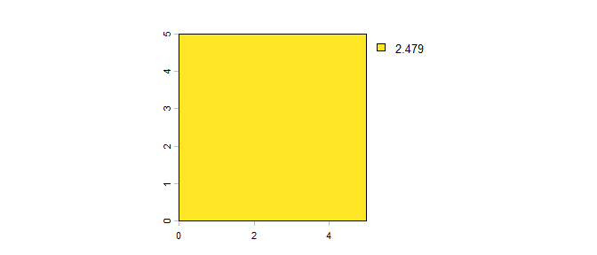

```r
terra::plot(map)
```

```r
## cleanup
unlink(dirname(tmpDir), recursive = TRUE)
```

# 2 Alternative database backends

By default, caching relies on a sqlite database for it’s backend. While this works in many situations, there are some important limitations of using sqlite for caching, including 1) speed; 2) concurrent transactions; 3) sharing database across machines or projects. Fortunately, `Cache` makes use of `DBI` package and thus supports several database backends, including mysql and postgresql.

See https://github.com/PredictiveEcology/SpaDES/wiki/Using-alternate-database-backends-for-Cache for further information on configuring these additional backends.

# 3 Reproducible workflow

In general, we feel that a liberal use of `Cache` will make a re-usable and reproducible work flow. `shiny` apps can be made, taking advantage of `Cache`. Indeed, much of the difficulty in managing data sets and saving them for future use, can be accommodated by caching.